# MyPers2

## Data screening

- **Country**: 1776914 observations (user id + country of provenance)
- **Dem**: 4282857 observations of 15 variables (including sex, date of birth, age, relationship status, etc.)
  - Besides sex, all variables present a huge number of missing data
  - 34.6% of the observations are coded as gender 0, 63.5% as 1 (1.88% is missing)
  - The variable age is strongly right skewed with a mean of 26 years, but 63% of the information is missing
- **Schwartz**: 12073 observations recording values from Schwartz Values Survey, which measures goals, aspirations and wishes that drive behaviour.
  - Values refer to SVS 57 (version of the test introdueced in the 1990s, more information can be found at https://github.com/artearthtech/cultural-values/issues/1)
  - Includes date of the test, test completed or not (0/1), and answers to the 57 questions
- **LDA (Latent Dirichlet allocation)**: 111431 observations of 600 variables
  - Each row represents a user, each column quantifies how much the user has in common with the 600 topics
  - Topics are stored in the variable *lda_topic_names*, that contains 600 rows and 5 columns (the 5 Facebook pages that mostly relate to the topic)
  - *Research question*: Do these topics identify coherent groups of fb pages that are internally homogenous, and are related to each other in a meaningful way? Does variation in topic usage correspond with certain characteristics? Do the topics match existing measures (e.g. sex, religion) where they should match?
- **SVD**: number of variables from the LDA data has been reduced to 100 topics
- **Religion**: 331671 observations containing political (e.g. conservative/liberal/moderate) and religious view

```r
country <- fread("country.csv")
dem <- fread("demog.csv")
schwartz <- fread("svs.csv")
lda <- fread("LDA600.csv")
svd <- fread("reduced_user_repr.csv")
religion <- fread("views.csv")

lda_topic_names <- read.table("lda_topic_names_utf8.csv", header = FALSE, quote = '"', sep = ",")
lda_topics <- lda_topic_names %>% mutate(topic_V = paste0("V", seq(1:nrow(lda_topic_names)) + 1))
lda_topics$topic_likes <- apply(lda_topics[,,2:6], 1, paste, collapse = "; ")
lda_topics <- lda_topics %>% select(topic_V, topic_likes)
```

Some data cleaning on political view:

```r
table(religion$political)

religion$political[religion$political=="anarchy"] <- "anarchist"

religion$political[religion$political=="democrat"] <- "democratic"
religion$political[religion$political=="democracy"] <- "democratic"

religion$political[religion$political==("dontreallycare")] <- "dontcare"
religion$political[religion$political==("idontreallycare")] <- "dontcare"
religion$political[religion$political==("notinterested")] <- "dontcare"
religion$political[religion$political==("whocares?")] <- "dontcare"
religion$political[religion$political==("whocares")] <- "dontcare"

religion$political[religion$political==("fuckpolitics")] <- "haters"
religion$political[religion$political==("hatepolitics")] <- "haters"
religion$political[religion$political==("idontlikepolitics")] <- "haters"
religion$political[religion$political==("politicssuck")] <- "haters"
religion$political[religion$political==("screwpolitics")] <- "haters"
religion$political[religion$political==("theyallsuck")] <- "haters"
religion$political[religion$political==("politicsuck")] <- "haters"
religion$political[religion$political==("ihatepolitics")] <- "haters"
religion$political[religion$political==("fuckthegovernment")] <- "haters"
religion$political[religion$political==("politicssucks")] <- "haters"


religion$political[religion$political==("nothanks")] <- "notpolitical"
religion$political[religion$political==("nothing")] <- "notpolitical"
religion$political[religion$political==("non")] <- "notpolitical"
religion$political[religion$political==("nope")] <- "notpolitical"
religion$political[religion$political==("nonpolitical")] <- "notpolitical"
religion$political[religion$political==("none")] <- "notpolitical"
religion$political[religion$political==("donthaveany")] <- "notpolitical"
religion$political[religion$political==("no")] <- "notpolitical"
```

Information included in different data sets that is based on the same users has been pulled together in the dataset ‘joined’.

```r
# Pull together information of same persons (through id key)
joined <- dem_sub[country, on="userid", nomatch=0]
joined <- religion[joined]
joined <- joined[schwartz, on="userid", nomatch=0]
joined <- joined[lda, on="userid", nomatch=0]

# Remove people that replied 0 on all the 57 Schwartz questions
all_zero <- joined[, q1:q57] %>% apply(1, function(x) all(x == 0))
joined <- joined[!all_zero]

# Show country of provenience of the 2029 people included in the variable joined
ans <- joined[, .N, by = country]
head(ans[order(N, decreasing = TRUE)], 20)
```

```
##            country    N
##  1:  united states 1551
##  2:         canada   69
##  3:    philippines   68
##  4:          india   33
##  5: united kingdom   33
##  6:      australia   33
##  7:      singapore   18
##  8:      indonesia   16
##  9:        romania   14
## 10:   south africa   13
## 11:       malaysia   12
## 12:    new zealand   11
## 13:       portugal    9
## 14:       pakistan    8
## 15:   saudi arabia    6
## 16:        finland    6
## 17:         brazil    6
## 18:        ireland    6
## 19:        germany    5
## 20:         serbia    5
```

```r
mean.values <- round(apply(lda[,-1], 2, mean), 4) # Mean values on people for each topic (600 values)
```

#### First check:

Checking concistency of these values and trying to understand if 0 or 1 is male (documentation was missing).

**Topic 17** (V18) is “The_Twilight_Saga”,“Twilight”,“Victoria’s_Secret”,“Victoria’s_Secret_Pink”,“Team_Twilight”

I expect a higher number of females with high lda score on this topic.

```r
selectionV18 <- joined[,which(V18>mean.values[18])]
table(joined[selectionV18, gender])
```

```
##
##  0  1
## 17 57
```

17 0 values and 57 1 values, I therefore suppose 1 is female

#### Second check:

**Topic 21** (V22) is “Cristiano_Ronaldo”,“Manchester_United”,“David_Beckham”,“Real_Madrid_C.F.”,“FC_Barcelona”

I expect a higher number of males with high lda score on this topic.

```r
selectionV22 <- joined[,which(V22>mean.values[22])]
table(joined[selectionV22, gender])
```

```
##
##  0  1
## 59 44
```

59 0 values and 44 1 values, these results are coherent with what we'd previously supposed.

# Religion

**Topic 61** (V62) is “Bible”,“The_Bible”,“God”,“The_Bible”,“Jesus_Daily”

First check different religion values

```r
table(joined$religion)
sum(is.na(joined$religion))#1669
length(joined$religion)#2029
```

There are only 360 non NA values for religion

```r
joined$religion <- gsub("[\r]", "", joined$religion) #removes all \r values at end of string
```

Same religion have different strings (e.g. christain, christian, christfollower, christian-churchofchrist, christianity), so I created one single str value for these

```r
joined$religion[joined$religion=="christain"] <- "christian"
joined$religion[joined$religion=="christfollower"] <- "christian"
joined$religion[joined$religion=="christian-churchofchrist"] <- "christian"
joined$religion[joined$religion=="christian-latter-daysaints"] <- "christian"
joined$religion[joined$religion=="christianity"] <- "christian"
joined$religion[joined$religion=="followerofjesuschrist"] <- "christian"
joined$religion[joined$religion=="followerofchrist"] <- "christian"
```

Checking whether Topic 61 actually identifies Christian people

```r
selectionV62 <- joined[,which(V62>mean.values[62])]
table(joined[selectionV62, religion])
```

```
##
##                    christian            christian-baptist
##                           20                            1
##           christian-catholic    christian-jehovahswitness
##                            4                            1
##           christian-lutheran christian-non-denominational
##                            1                            1
##        christian-pentecostal       christian-presbyterian
##                            1                            1
##         christian-protestant                        hindu
##                            1                            2
##                ibelieveingod                     lutheran
##                            1                            1
##                        other                romancatholic
##                            1                            1
##        unitarianuniversalist
##                            1
```

Results confirm that topics identify coherents group of people.

## SVS 57

The SVS survey presents two lists of value items. The first contains 30 items that "describe potentially desirable end-states in noun form; the second contains 27 items that describe potentially desirable ways of acting in adjective form".

Respondents rate the importance of each value item ”as a guiding principle in MY life" on a 9-point scale labeled 7 (*of supreme importance*), 6 (*very important*), ..., 0 (not important), -1 (*opposed to my values*).

SVS57 scores have been computed for each individual, following the SVS guidlines that link each question to a personal characteristic as follows:

**Power** = 3, 12, 27

**Achievement** = 34, 43, 55, 39

**Hedonism** = 4, 50, 57

**Stimulation** = 9, 25, 37

**Selfdirection** = 5, 16, 31, 41, 53

**Universalism** = 1, 17, 24, 26, 29, 30, 35, 38

**Benevolence** = 33, 45, 49, 52, 54

**Tradition** = 36, 44, 51, 32

**Conformity** = 11, 20, 40, 47

**Security** = 13, 15, 56, 8, 22

However, questions 6, 23 and 46 do not have a particular indication.

These values are considered as in the **Schwartz Circumplex Model** *(Schawrtz, 2012)*, which defines 10 value domains as in the following picture:

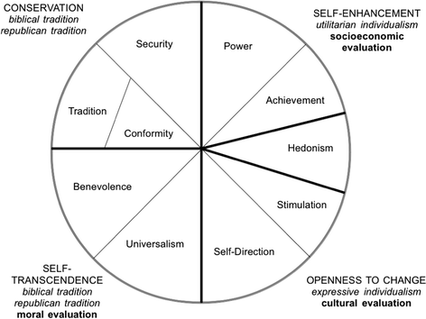

The values are organized along two bipolar dimensions to “summarize the oppositions between competing values”.

As the figure above shows, “one dimension contrasts ‘*openness to change*’ and ‘*conservation*’ values. This dimension captures the conflict between values that emphasize independence of thought, action, and feelings and readiness for change (*self-direction, stimulation*) and values that emphasize order, selfrestriction, preservation of the past, and resistance to change (*security, conformity, tradition*).

The second dimension contrasts ‘*self-enhancement*’ and *‘self-transcendence’* values. This dimension captures the conflict between values that emphasize concern for the welfare and interests of others (*universalism, benevolence*) and values that emphasize pursuit of one’s own interests and relative success and dominance over others (*power, achievement*).

*Hedonism* shares elements of both openness to change and self-enhancement.”

# Data checking

```r
which(colnames(joined)=="q1")
```

```
## [1] 13
```

```r
which(colnames(joined)=="q57")
```

```
## [1] 69
```

```r
joined_swr <- joined[,13:69]
numbers_of_zeros <- rowSums(joined_swr==0)
```

For all the 2029 individuals, 0 values are either 0 or 27.

Further checking why this weird behaviour is happening:

```r
joined_swr[19,]
```

```
##    q1 q2 q3 q4 q5 q6 q7 q8 q9 q10 q11 q12 q13 q14 q15 q16 q17 q18 q19 q20
## 1:  9  6  3  6  8  7  8  5  5   6   8   4   7   7   7   7   7   3   9   8
##    q21 q22 q23 q24 q25 q26 q27 q28 q29 q30 q31 q32 q33 q34 q35 q36 q37 q38
## 1:   7   8   4   9   7   8   6   8   9   8   0   0   0   0   0   0   0   0
##    q39 q40 q41 q42 q43 q44 q45 q46 q47 q48 q49 q50 q51 q52 q53 q54 q55 q56
## 1:   0   0   0   0   0   0   0   0   0   0   0   0   0   0   0   0   0   0
##    q57
## 1:   0
```

```r
joined_swr[325,]
```

```
##    q1 q2 q3 q4 q5 q6 q7 q8 q9 q10 q11 q12 q13 q14 q15 q16 q17 q18 q19 q20
## 1:  6  8  1  7  8  9  8  5  8   9   8   2   5   9   5   8   6   6   9   7
##    q21 q22 q23 q24 q25 q26 q27 q28 q29 q30 q31 q32 q33 q34 q35 q36 q37 q38
## 1:   7   8   6   2   9   9   2   8   6   7   0   0   0   0   0   0   0   0
##    q39 q40 q41 q42 q43 q44 q45 q46 q47 q48 q49 q50 q51 q52 q53 q54 q55 q56
## 1:   0   0   0   0   0   0   0   0   0   0   0   0   0   0   0   0   0   0
##    q57
## 1:   0
```

It is now clear that all people that have 27 zeros in their answers did not replie to the second part of the test. From q31 on, all answers are 0.

I will replace these values by NA.

```r
no_second_part <- which(numbers_of_zeros==27)
which(colnames(joined)=="q31")
which(colnames(joined)=="q57")
joined[no_second_part,43:69] <- NA

joined_excluding_na <- joined[-no_second_part,] #1866 units
```

# Factor Analysis

**Factor analysis with factorQ rotation**

```r
library(GPArotation)
bifactor <- factanal(joined_excluding_na[, q1:q57], factors = 3, scores = "regression", rotation = "bifactorQ")
bifactor$loadings
```

```
##
## Loadings:
##     Factor1 Factor2 Factor3
## q1   0.422  -0.306  -0.137
## q2   0.411  -0.231
## q3   0.273   0.580
## q4   0.406   0.273  -0.316
## q5   0.376  -0.101  -0.289
## q6   0.328  -0.290   0.286
## q7   0.368
## q8   0.448   0.160   0.204
## q9   0.532   0.169  -0.313
## q10  0.380
## q11  0.439           0.282
## q12  0.278   0.586
## q13  0.418   0.172   0.296
## q14  0.406
## q15  0.313   0.167
## q16  0.417  -0.176  -0.307
## q17  0.399  -0.356
## q18  0.397           0.392
## q19  0.343  -0.190
## q20  0.376           0.331
## q21  0.348
## q22  0.472           0.187
## q23  0.390   0.420
## q24  0.447  -0.326  -0.154
## q25  0.480          -0.289
## q26  0.383  -0.171
## q27  0.386   0.457   0.110
## q28  0.417  -0.125
## q29  0.489  -0.253  -0.297
## q30  0.445  -0.262
## q31  0.383   0.127  -0.115
## q32  0.200           0.250
## q33  0.455           0.244
## q34  0.485   0.237   0.115
## q35  0.349  -0.264  -0.246
## q36  0.418  -0.205   0.314
## q37  0.480   0.141  -0.237
```

[output cut: 10 more lines]

```
## q48  0.308
## q49  0.485  -0.336   0.178
## q50  0.445   0.194  -0.276
## q51  0.306           0.509
## q52  0.472           0.310
## q53  0.414          -0.295
## q54  0.334  -0.356   0.248
## q55  0.477   0.404
## q56  0.486   0.175   0.257
## q57  0.428   0.298  -0.244
##
##                Factor1 Factor2 Factor3
## SS loadings      9.723   3.342   3.074
## Proportion Var   0.171   0.059   0.054
## Cumulative Var   0.171   0.229   0.283
```

The first factor has only positive values.

Power (3, 12, 27) is catched by very high positive loadings in the second factor. Same for Achievement (34, 43, 55, 39), with positive but lower loadings.

Universalism (1, 17, 24, 26, 29, 30, 35, 38) is catched by negative loadings in the second factor.

Hedonism (4, 50, 57) loads on both the second (positively) and third (negatevely) factors, coherently for each item. Same for Stimulation (9, 50, 57).

Security (13, 15, 56, 8, 22) has positive loadings for both the second and third factor.

Benevolence (33, 45, 49, 52, 54) has positive loadings for the third factor and, for some items, negative ones on the second factor.

Tradition (36, 44, 51, 32) and Conformity (11, 20, 40, 47) are catched by positive loadings in the third factor. Selfdirection (5, 16, 31, 41, 53) loads negatively on the third factor.

Following the Shwartz model:

- The third factor well represents Conservation (positive loadings on Conformity + Tradition + Security) and Openess (negative loadings on Stimulation + Selfdirection).
- The second factor well represents Self enhancement (positive loadings on Achivement + Power + Hedonism) and Self transcendence (negative loadings on Benevolence + Universalism).

Looking at the theoretical model scheme, this is exactly what was expected. The model is able to catch these relations from the survey data in a meaningful way.

Factor 1, 2 and 3 scores have been added to the dataset.

```r
joined_excluding_na <- cbind(joined_excluding_na, bifactor$scores)
```

# Train/test split

- **Train set** has 90% of the total people from US (1305 persons)
- **Test set** has the remaining 10% from US + all people from other countries with at least 20 units (countries in the European Union have been joined together so to reach a sufficient amount of units). Test set includes 380 persons:
- 146 people from US
- 59 people from Canada
- 55 people from the Philippines
- 35 people from the Europen Union (Czech Republic, Portugal, Italy, Netherlands, Norway, Serbia, Sweden, Spain, Finland, France, Germany, Denmark)
- 29 people from India
- 28 people from UK
- 28 people from Australia

```r
test_countries <- table(joined_excluding_na$country)

joined_US<- subset(joined_excluding_na, country=="united states")
joined_other_coutries <- subset(joined_excluding_na, country=="czech republic" | country=="portugal" | country=="italy" | country=="netherlands" | country == "serbia" | country=="norway" | country=="sweden" | country=="Spain" | country== "finland" | country=="france" | country=="germany" | country=="denmark" | country=="united kingdom" | country=="australia" | country=="india" | country=="philippines" | country=="canada")


idx <- seq(nrow(joined_US))
idx_train <- sample(idx, size = floor(nrow(joined_US) * 0.9), replace = FALSE)
idx_test <- idx[!idx %in% idx_train]

joined_train <- joined_US[idx_train] #100% US (90% of total US)
joined_test_US <- joined_US[idx_test] # remaning 10% US

joined_test <- rbind(joined_other_coutries, joined_test_US) #now train set is a mix of all countries (> 20) + some from US

#Extract row indices for each country
US <- joined_test[,which(country=="united states")]
Canada <- joined_test[,which(country=="canada")]
Philippines <- joined_test[,which(country=="philippines")]
India <- joined_test[,which(country=="india")]
Australia <- joined_test[,which(country=="australia")]
UK <- joined_test[,which(country=="united kingdom")]
Europe <- joined_test[,which(country=="czech republic" | country=="portugal" | country=="italy" | country=="netherlands" | country == "serbia" | country=="norway" | country=="sweden" | country=="Spain" | country== "finland" | country=="france" | country=="germany" | country=="denmark")]
```

Two models have been built:

- Model 1: using Factor 2
- Model 2: using Factor 3

**Model 1**

Parameters optimisation has been investigated:

```r
#Shuffle the data for 10-cross validation
#This will be done only on the train data (that will be sub-divided in test/train) otherwise we do not have enought info for the 1-k test afterwards

joined_10fold<-joined_train[sample(nrow(joined_train)),]
idx_10fold <- seq(nrow(joined_10fold))
trainset_10fold <-sample(idx_10fold, size = floor(nrow(joined_10fold) * 0.9), replace = FALSE)
testset_10fold <- idx_10fold [!idx_10fold  %in% trainset_10fold]  #Current test set

joined_10fold_train <- joined_10fold[trainset_10fold]
joined_10fold_test <- joined_10fold[testset_10fold] # This will be used only once, after the grid optimization. This test set (part of the 9-fold-trainset) will be used as test set for the gridsearch. I'm not sure if this is what you meant or if you meant a proper k-fold validation analysis using each k-fold-subsample as test set

watchlist_grid2 <- list(train=xgb.DMatrix(data = as.matrix(joined_10fold_train[,V2:V601]),
                                    label = as.matrix(joined_10fold_train[, Factor2])),
                  test=xgb.DMatrix(data = as.matrix(joined_10fold_test[, V2:V601]),
                                   label = as.matrix(joined_10fold_test[, Factor2])))

# hyper-parameter search
searchGrid = expand.grid(
nrounds = 50,
eta = c(0.01, 0.001, 0.0001),
max_depth = c(2, 4, 6, 8, 10),
subsample=c(0.4, 0.5, 0.6, 0.7),
lambda=c(0.01, 0.1, 0.8),
alpha=c(0.001,0.01,0.1)
)

rmseHyperparameters <- apply(searchGrid, 1, function(parameterList){

  #Extract Parameters to test
  currentmax_depth <- parameterList[["max_depth"]]
  currentsubsample <- parameterList[["subsample"]]
  currentlambda <- parameterList[["lambda"]]
  currentEta <- parameterList[["eta"]]
  currentalpha <- parameterList[["alpha"]]

  xgb_2 <- xgb.train(data =  watchlist_grid2$train,
                       metrics = "rmse", "eval_metric" = "rmse",
                     "objective" = "reg:linear", "max.depth" = currentmax_depth, "eta" = currentEta,
                     "subsample" = currentsubsample, "lambda" = currentlambda, "alpha" = currentalpha, nrounds=50)

pred_xg_2 <- predict(xgb_2, newdata = as.matrix(joined_10fold_test[, V2:V601]))

y_test_2 <- as.numeric(joined_10fold_test[, Factor2])

corr=cor(pred_xg_2, y_test_2)^2

mse_xgboost_model1 <- mean((joined_10fold_test[,Factor2] - pred_xg_2)^2)
  output <- return(c(corr, mse_xgboost_model1, currentsubsample, currentlambda, currentmax_depth, currentEta, currentalpha))

})

output <- as.data.frame(t(rmseHyperparameters))
varnames <- c("corr", "mse", "subsample", "lambda", "max_depth", "eta", "alpha")
names(output) <- varnames

head(output[order(output$corr, decreasing = TRUE),],5)
```

[output not shown]

Running this model on the actual test set (the one in *watchlist*, previously specified as 10% of total US + all other countries):

```r
watchlist <- list(train=xgb.DMatrix(data = as.matrix(joined_train[,V2:V601]),
                                    label = as.matrix(joined_train[, Factor2])),
                  test=xgb.DMatrix(data = as.matrix(joined_test[, V2:V601]),
                                   label = as.matrix(joined_test[, Factor2])))

xgb_2 <- xgb.train(data = watchlist$train,
                 eta = 0.01,
                 max_depth = 10,
                 nround = 30,
                 subsample = 0.6,
                 lambda = 0.01,
                 alpha = 0.1,
                 colsample_bytree = 0.5,
                 watchlist = watchlist,
                 seed = 201798,
                 eval_metric = c("mae", "rmse"),
                 objective = "reg:linear",
                 nthread = 3, verbose=0)

# Prediction from xgb of factor scores based on LDA (test data)
pred_xg_2 <- predict(xgb_2, newdata = as.matrix(joined_test[, V2:V601]))

# Factor score (test data)
y_test_2 <- as.numeric(joined_test[, Factor2])
```

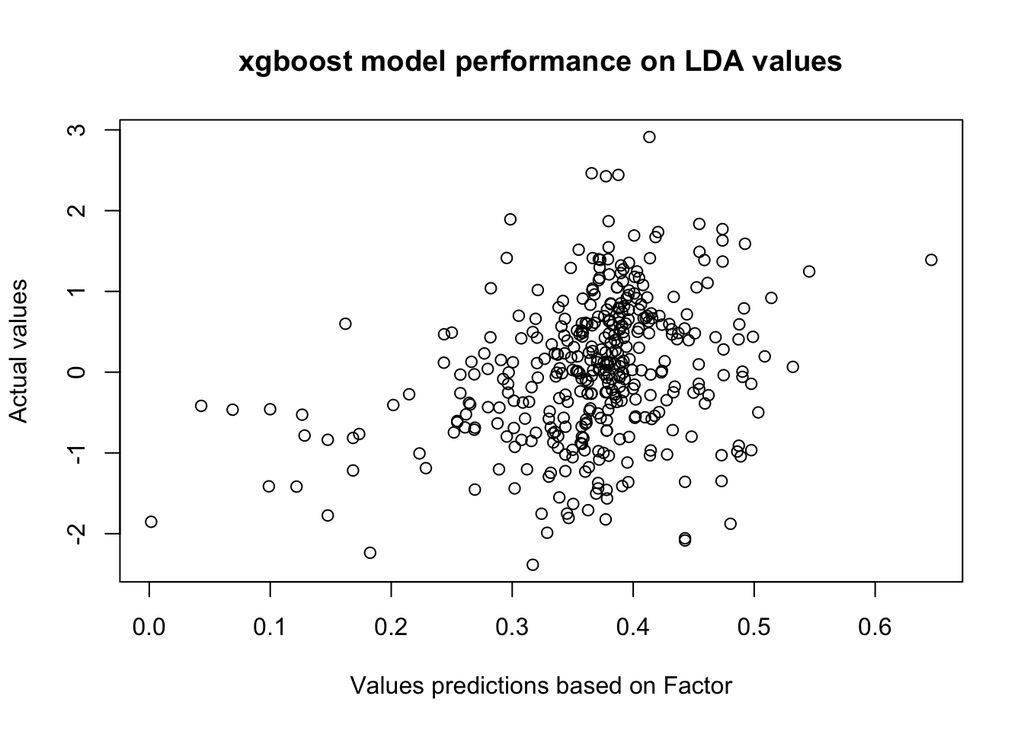

```r
# Strength of relationship factor score and its prediction in test data
plot(pred_xg_2, y_test_2, xlab="Values predictions based on Factor", ylab="Actual values", main="xgboost model performance on LDA values")
```

```r
mse_xgboost_model1 <- mean((joined_test[,Factor2] - pred_xg_2)^2)
mse_onlyUS <-  mean((joined_test[US,Factor2] - pred_xg_2[US])^2)
mse_canads <- mean((joined_test[Canada,Factor2] - pred_xg_2[Canada])^2)
mse_philippines <- mean((joined_test[Philippines,Factor2] - pred_xg_2[Philippines])^2)
mse_india <- mean((joined_test[India,Factor2] - pred_xg_2[India])^2)
mse_europe <- mean((joined_test[Europe,Factor2] - pred_xg_2[Europe])^2)
mse_australia <- mean((joined_test[Australia,Factor2] - pred_xg_2[Australia])^2)
mse_uk <- mean((joined_test[UK,Factor2] - pred_xg_2[UK])^2)

sd_xgboost_model1 <- sd((joined_test[,Factor2] - pred_xg_2)^2)
sd_onlyUS <-  sd((joined_test[US,Factor2] - pred_xg_2[US])^2)
sd_canads <- sd((joined_test[Canada,Factor2] - pred_xg_2[Canada])^2)
sd_philippines <- sd((joined_test[Philippines,Factor2] - pred_xg_2[Philippines])^2)
sd_india <- sd((joined_test[India,Factor2] - pred_xg_2[India])^2)
sd_europe <- sd((joined_test[Europe,Factor2] - pred_xg_2[Europe])^2)
sd_australia <- sd((joined_test[Australia,Factor2] - pred_xg_2[Australia])^2)
sd_uk <- sd((joined_test[UK,Factor2] - pred_xg_2[UK])^2)

MAE_xgboost <- median(abs(joined_test[,Factor2] - pred_xg_2))
MAE_onlyUS <-  median(abs((joined_test[US,Factor2] - pred_xg_2[US])))
MAE_canads <- median(abs((joined_test[Canada,Factor2] - pred_xg_2[Canada])))
MAE_philippines <- median(abs((joined_test[Philippines,Factor2] - pred_xg_2[Philippines])))
MAE_india <- median(abs((joined_test[India,Factor2] - pred_xg_2[India])))
MAE_europe <- median(abs((joined_test[Europe,Factor2] - pred_xg_2[Europe])))
MAE_australia <- median(abs((joined_test[Australia,Factor2] - pred_xg_2[Australia])))
MAE_uk <- median(abs((joined_test[UK,Factor2] - pred_xg_2[UK])))

R2=cor(pred_xg_2, y_test_2)^2
R2_onlyUS <-  cor(joined_test[US,Factor2], pred_xg_2[US])^2
R2_canads <- cor(joined_test[Canada,Factor2], pred_xg_2[Canada])^2
R2_philippines <- cor(joined_test[Philippines,Factor2], pred_xg_2[Philippines])^2
R2_india <- cor(joined_test[India,Factor2], pred_xg_2[India])^2
R2_europe <- cor(joined_test[Europe,Factor2], pred_xg_2[Europe])^2
R2_australia <- cor(joined_test[Australia,Factor2], pred_xg_2[Australia])^2
R2_uk <- cor(joined_test[UK,Factor2], pred_xg_2[UK])^2


MSElist=list("Total"=mse_xgboost_model1, "US"=mse_onlyUS, "Canada"=mse_canads, "Philippines"=mse_philippines, "India"=mse_india, "European Union"=mse_europe, "Australia"=mse_australia, "UK"=mse_uk)

SDlist=list("Total"=sd_xgboost_model1, "US"=sd_onlyUS, "Canada"=sd_canads, "Philippines"=sd_philippines, "India"=sd_india, "Europian Union"=sd_europe, "Australia"=sd_australia, "UK"=sd_uk)

MAElist=list("Total"=MAE_xgboost, "US"=MAE_onlyUS, "Canada"=MAE_canads, "Philippines"=MAE_philippines, "India"=MAE_india, "Europian Union"=MAE_europe, "Australia"=MAE_australia, "UK"=MAE_uk)

R2list=list("Total"=R2, "US"=R2_onlyUS, "Canada"=R2_canads, "Philippines"=R2_philippines, "India"=R2_india, "Europian Union"=R2_europe, "Australia"=R2_australia, "UK"=R2_uk)

LIST_xgboost_model1=round(mapply(cbind,MSElist, SDlist, MAElist, R2list),3)
rownames(LIST_xgboost_model1) <- c("MSE", "SD", "MAE", "R squared")
LIST_xgboost_model1
```

```
##           Total    US Canada Philippines India European Union Australia
## MSE       0.861 0.785  1.127       0.576 0.932          1.355     0.679
## SD        1.230 1.142  1.353       0.860 1.320          1.792     1.252
## MAE       0.614 0.639  0.739       0.454 0.648          0.660     0.364
## R squared 0.095 0.224  0.088       0.016 0.030          0.039     0.001
##              UK
## MSE       0.754
## SD        0.821
## MAE       0.723
## R squared 0.173
```

**Model 2**

Model used in the prediction of factor 3 from LDA scores.

Parameters optimisation has been investigated:

```r
watchlist_grid2 <- list(train=xgb.DMatrix(data = as.matrix(joined_10fold_train[,V2:V601]),
                                    label = as.matrix(joined_10fold_train[, Factor3])),
                  test=xgb.DMatrix(data = as.matrix(joined_10fold_test[, V2:V601]),
                                   label = as.matrix(joined_10fold_test[, Factor3])))

# hyper-parameter search
searchGrid = expand.grid(
nrounds = 30,
eta = c(0.01, 0.001, 0.0001),
max_depth = c(2, 4, 6, 8, 10),
subsample=c(0.4, 0.5, 0.6, 0.7),
lambda=c(0.01, 0.1, 0.8),
alpha=c(0.001,0.01,0.1)
)

rmseHyperparameters <- apply(searchGrid, 1, function(parameterList){

  #Extract Parameters to test
  currentmax_depth <- parameterList[["max_depth"]]
  currentsubsample <- parameterList[["subsample"]]
  currentlambda <- parameterList[["lambda"]]
  currentEta <- parameterList[["eta"]]
  currentalpha <- parameterList[["alpha"]]

  xgb_2 <- xgb.train(data =  watchlist_grid2$train,
                       metrics = "rmse", "eval_metric" = "rmse",
                     "objective" = "reg:linear", "max.depth" = currentmax_depth, "eta" = currentEta,
                     "subsample" = currentsubsample, "lambda" = currentlambda, "alpha" = currentalpha, nrounds=30)

pred_xg_2 <- predict(xgb_2, newdata = as.matrix(joined_10fold_test[, V2:V601]))

y_test_2 <- as.numeric(joined_10fold_test[, Factor3])

corr=cor(pred_xg_2, y_test_2)^2

mse_xgboost_model1 <- mean((joined_10fold_test[,Factor3] - pred_xg_2)^2)
  output <- return(c(corr, mse_xgboost_model1, currentsubsample, currentlambda, currentmax_depth, currentEta, currentalpha))

})

output <- as.data.frame(t(rmseHyperparameters))
varnames <- c("corr", "mse", "subsample", "lambda", "max_depth", "eta", "alpha")
names(output) <- varnames

head(output[order(output$corr, decreasing = TRUE),],5)
```

```
##          corr       mse subsample lambda max_depth   eta alpha
## 433 0.3394348 0.8419870       0.4    0.1        10 0.010 0.100
## 149 0.3343467 1.0189385       0.5    0.8        10 0.001 0.001
## 74  0.3336550 1.0178292       0.4    0.1        10 0.001 0.001
## 163 0.3333360 0.8423718       0.6    0.8        10 0.010 0.001
## 328 0.3324813 0.8461914       0.5    0.8        10 0.010 0.010
```

```r
watchlist <- list(train=xgb.DMatrix(data = as.matrix(joined_train[,V2:V601]),
                                    label = as.matrix(joined_train[, Factor3])),
                  test=xgb.DMatrix(data = as.matrix(joined_test[, V2:V601]),
                                   label = as.matrix(joined_test[, Factor3])))

xgb_2 <- xgb.train(data = watchlist$train,
                 eta = 0.01,
                 max_depth = 10,
                 nround = 150,
                 subsample = 0.5,
                 lambda = 0.01,
                 alpha = 0.1,
                 colsample_bytree = 0.5,
                 watchlist = watchlist,
                 seed = 201798,
                 eval_metric = c("mae", "rmse"),
                 objective = "reg:linear",
                 nthread = 3, verbose=0)

# Prediction from xgb of factor scores based on LDA (test data)
pred_xg_2 <- predict(xgb_2, newdata = as.matrix(joined_test[, V2:V601]))

# Factor score (test data)
y_test_2 <- as.numeric(joined_test[, Factor3])
```

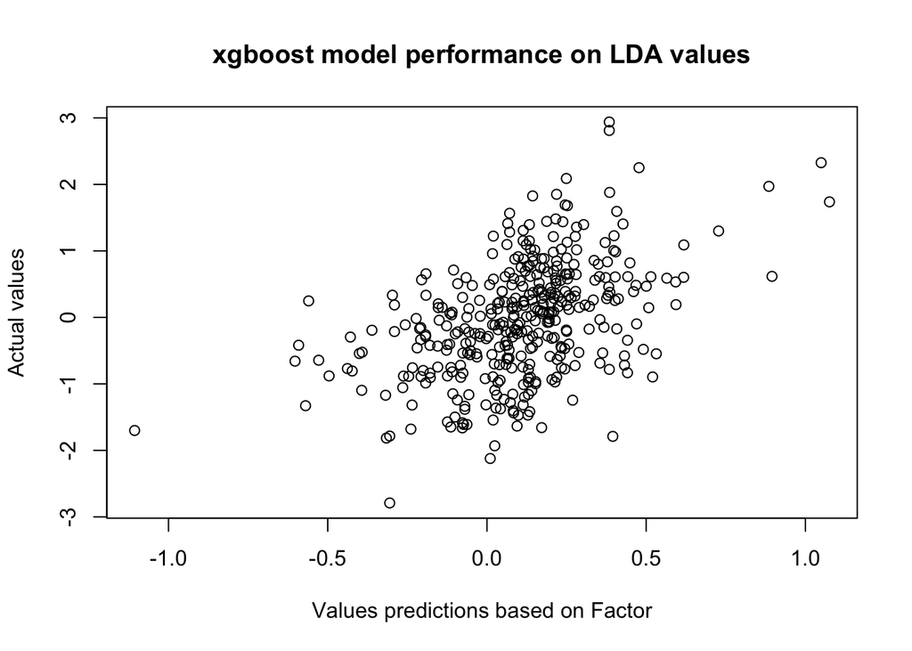

```r
# Strength of relationship factor score and its prediction in test data
plot(pred_xg_2, y_test_2, xlab="Values predictions based on Factor", ylab="Actual values", main="xgboost model performance on LDA values")
```

```r
mse_xgboost_model1 <- mean((joined_test[,Factor3] - pred_xg_2)^2)
mse_onlyUS <-  mean((joined_test[US,Factor3] - pred_xg_2[US])^2)
mse_canads <- mean((joined_test[Canada,Factor3] - pred_xg_2[Canada])^2)
mse_philippines <- mean((joined_test[Philippines,Factor3] - pred_xg_2[Philippines])^2)
mse_india <- mean((joined_test[India,Factor3] - pred_xg_2[India])^2)
mse_europe <- mean((joined_test[Europe,Factor3] - pred_xg_2[Europe])^2)
mse_australia <- mean((joined_test[Australia,Factor3] - pred_xg_2[Australia])^2)
mse_uk <- mean((joined_test[UK,Factor3] - pred_xg_2[UK])^2)

sd_xgboost_model1 <- sd((joined_test[,Factor3] - pred_xg_2)^2)
sd_onlyUS <-  sd((joined_test[US,Factor3] - pred_xg_2[US])^2)
sd_canads <- sd((joined_test[Canada,Factor3] - pred_xg_2[Canada])^2)
sd_philippines <- sd((joined_test[Philippines,Factor3] - pred_xg_2[Philippines])^2)
sd_india <- sd((joined_test[India,Factor3] - pred_xg_2[India])^2)
sd_europe <- sd((joined_test[Europe,Factor3] - pred_xg_2[Europe])^2)
sd_australia <- sd((joined_test[Australia,Factor3] - pred_xg_2[Australia])^2)
sd_uk <- sd((joined_test[UK,Factor3] - pred_xg_2[UK])^2)

MAE_xgboost <- median(abs(joined_test[,Factor3] - pred_xg_2))
MAE_onlyUS <-  median(abs((joined_test[US,Factor3] - pred_xg_2[US])))
MAE_canads <- median(abs((joined_test[Canada,Factor3] - pred_xg_2[Canada])))
MAE_philippines <- median(abs((joined_test[Philippines,Factor3] - pred_xg_2[Philippines])))
MAE_india <- median(abs((joined_test[India,Factor3] - pred_xg_2[India])))
MAE_europe <- median(abs((joined_test[Europe,Factor3] - pred_xg_2[Europe])))
MAE_australia <- median(abs((joined_test[Australia,Factor3] - pred_xg_2[Australia])))
MAE_uk <- median(abs((joined_test[UK,Factor3] - pred_xg_2[UK])))

R2=cor(pred_xg_2, y_test_2)^2
R2_onlyUS <-  cor(joined_test[US,Factor3], pred_xg_2[US])^2
R2_canads <- cor(joined_test[Canada,Factor3], pred_xg_2[Canada])^2
R2_philippines <- cor(joined_test[Philippines,Factor3], pred_xg_2[Philippines])^2
R2_india <- cor(joined_test[India,Factor3], pred_xg_2[India])^2
R2_europe <- cor(joined_test[Europe,Factor3], pred_xg_2[Europe])^2
R2_australia <- cor(joined_test[Australia,Factor3], pred_xg_2[Australia])^2
R2_uk <- cor(joined_test[UK,Factor3], pred_xg_2[UK])^2


MSElist=list("Total"=mse_xgboost_model1, "US"=mse_onlyUS, "Canada"=mse_canads, "Philippines"=mse_philippines, "India"=mse_india, "European Union"=mse_europe, "Australia"=mse_australia, "UK"=mse_uk)

SDlist=list("Total"=sd_xgboost_model1, "US"=sd_onlyUS, "Canada"=sd_canads, "Philippines"=sd_philippines, "India"=sd_india, "Europian Union"=sd_europe, "Australia"=sd_australia, "UK"=sd_uk)

MAElist=list("Total"=MAE_xgboost, "US"=MAE_onlyUS, "Canada"=MAE_canads, "Philippines"=MAE_philippines, "India"=MAE_india, "Europian Union"=MAE_europe, "Australia"=MAE_australia, "UK"=MAE_uk)

R2list=list("Total"=R2, "US"=R2_onlyUS, "Canada"=R2_canads, "Philippines"=R2_philippines, "India"=R2_india, "Europian Union"=R2_europe, "Australia"=R2_australia, "UK"=R2_uk)

LIST_xgboost_model2=round(mapply(cbind,MSElist, SDlist, MAElist, R2list),3)
rownames(LIST_xgboost_model2) <- c("MSE", "SD", "MAE", "R squared")
LIST_xgboost_model2
```

```
##           Total    US Canada Philippines India European Union Australia
## MSE       0.633 0.539  0.800       0.613 0.588          0.920     0.626
## SD        0.934 0.757  1.308       0.772 0.774          1.331     0.901
## MAE       0.513 0.491  0.472       0.556 0.567          0.658     0.486
## R squared 0.218 0.264  0.140       0.197 0.070          0.115     0.382
##              UK
## MSE       0.508
## SD        0.628
## MAE       0.482
## R squared 0.297
```

Other methods have been applied and compared to *xgboost*:

# **penalized linear regression with the glmnet packsage**

Glmnet: package that fits a generalized linear model via penalized maximum likelihood

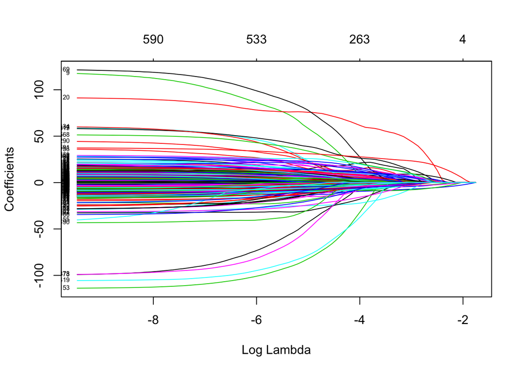

```r
fit2 = glmnet(as.matrix(joined_train[,V2:V601]), as.numeric(joined_train[, Factor2]))

plot(fit2, xvar = "lambda", label = TRUE)
```

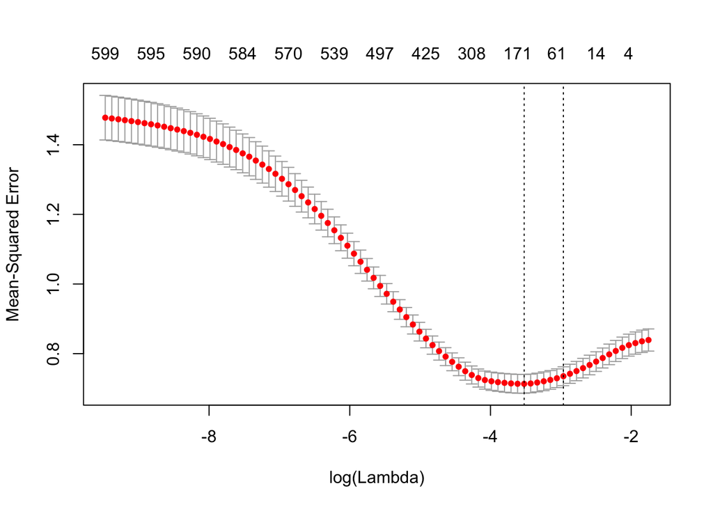

```r
predictions=predict(fit2, newx = as.matrix(joined_test[,V2:V601]))

#Optimal lambda value

cvfit2 = cv.glmnet(as.matrix(joined_train[,V2:V601]), as.numeric(joined_train[, Factor2]))
plot(cvfit2)
```

```r
cvfit2$lambda.min
```

```
## [1] 0.02954906
```

```r
predictions=predict(cvfit2, newx = as.matrix(joined_test[,V2:V601]), s = "lambda.min")
```

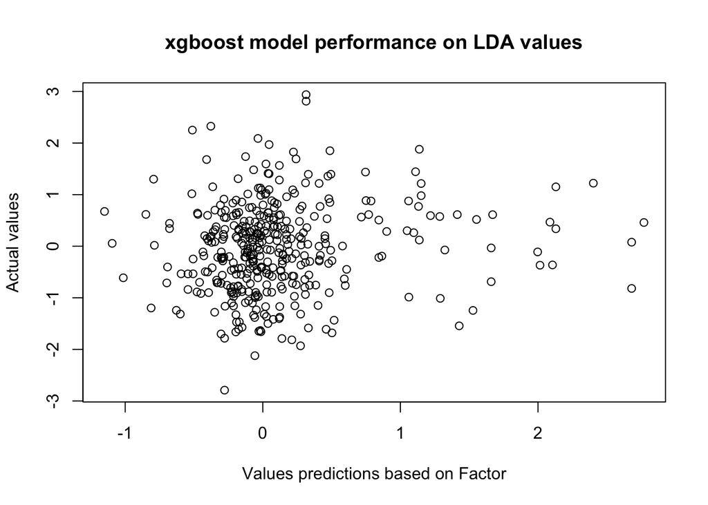

```r
plot(predictions, y_test_2, xlab="Values predictions based on Factor", ylab="Actual values", main="xgboost model performance on LDA values")
```

```r
mse_xgboost_model1 <- mean((joined_test[,Factor3] - predictions)^2)
mse_onlyUS <-  mean((joined_test[US,Factor3] - predictions[US])^2)
mse_canads <- mean((joined_test[Canada,Factor3] - predictions[Canada])^2)
mse_philippines <- mean((joined_test[Philippines,Factor3] - predictions[Philippines])^2)
mse_india <- mean((joined_test[India,Factor3] - predictions[India])^2)
mse_europe <- mean((joined_test[Europe,Factor3] - predictions[Europe])^2)
mse_australia <- mean((joined_test[Australia,Factor3] - predictions[Australia])^2)
mse_uk <- mean((joined_test[UK,Factor3] - predictions[UK])^2)

sd_xgboost_model1 <- sd((joined_test[,Factor3] - predictions)^2)
sd_onlyUS <-  sd((joined_test[US,Factor3] - predictions[US])^2)
sd_canads <- sd((joined_test[Canada,Factor3] - predictions[Canada])^2)
sd_philippines <- sd((joined_test[Philippines,Factor3] - predictions[Philippines])^2)
sd_india <- sd((joined_test[India,Factor3] - predictions[India])^2)
sd_europe <- sd((joined_test[Europe,Factor3] - predictions[Europe])^2)
sd_australia <- sd((joined_test[Australia,Factor3] - predictions[Australia])^2)
sd_uk <- sd((joined_test[UK,Factor3] - predictions[UK])^2)

MAE_xgboost <- median(abs(joined_test[,Factor3] - predictions))
MAE_onlyUS <-  median(abs((joined_test[US,Factor3] - predictions[US])))
MAE_canads <- median(abs((joined_test[Canada,Factor3] - predictions[Canada])))
MAE_philippines <- median(abs((joined_test[Philippines,Factor3] - predictions[Philippines])))
MAE_india <- median(abs((joined_test[India,Factor3] - predictions[India])))
MAE_europe <- median(abs((joined_test[Europe,Factor3] - predictions[Europe])))
MAE_australia <- median(abs((joined_test[Australia,Factor3] - predictions[Australia])))
MAE_uk <- median(abs((joined_test[UK,Factor3] - predictions[UK])))

R2=cor(predictions, y_test_2)^2
R2_onlyUS <-  cor(joined_test[US,Factor3], predictions[US])^2
R2_canads <- cor(joined_test[Canada,Factor3], predictions[Canada])^2
R2_philippines <- cor(joined_test[Philippines,Factor3], predictions[Philippines])^2
R2_india <- cor(joined_test[India,Factor3], predictions[India])^2
R2_europe <- cor(joined_test[Europe,Factor3], predictions[Europe])^2
R2_australia <- cor(joined_test[Australia,Factor3], predictions[Australia])^2
R2_uk <- cor(joined_test[UK,Factor3], predictions[UK])^2


MSElist=list("Total"=mse_xgboost_model1, "US"=mse_onlyUS, "Canada"=mse_canads, "Philippines"=mse_philippines, "India"=mse_india, "European Union"=mse_europe, "Australia"=mse_australia, "UK"=mse_uk)

SDlist=list("Total"=sd_xgboost_model1, "US"=sd_onlyUS, "Canada"=sd_canads, "Philippines"=sd_philippines, "India"=sd_india, "Europian Union"=sd_europe, "Australia"=sd_australia, "UK"=sd_uk)

MAElist=list("Total"=MAE_xgboost, "US"=MAE_onlyUS, "Canada"=MAE_canads, "Philippines"=MAE_philippines, "India"=MAE_india, "Europian Union"=MAE_europe, "Australia"=MAE_australia, "UK"=MAE_uk)

R2list=list("Total"=R2, "US"=R2_onlyUS, "Canada"=R2_canads, "Philippines"=R2_philippines, "India"=R2_india, "Europian Union"=R2_europe, "Australia"=R2_australia, "UK"=R2_uk)

LIST_glmnet_model1=round(mapply(cbind,MSElist, SDlist, MAElist, R2list),3)
rownames(LIST_glmnet_model1) <- c("MSE", "SD", "MAE", "R squared")
LIST_glmnet_model1
```

```
##           Total    US Canada Philippines India European Union Australia
## MSE       0.983 0.730  0.818       1.334 2.255          0.915     0.962
## SD        1.565 1.080  1.315       2.265 2.544          1.352     1.225
## MAE       0.615 0.540  0.564       0.796 1.056          0.610     0.835
## R squared 0.012 0.012  0.057       0.003 0.000          0.001     0.008
##              UK
## MSE       0.750
## SD        1.077
## MAE       0.652
## R squared 0.009
```

** Model 2 **

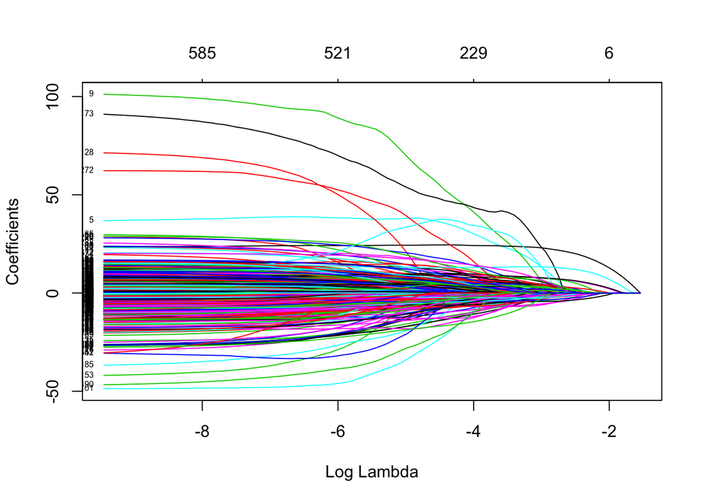

```r
fit2 = glmnet(as.matrix(joined_train[,V2:V601]), as.numeric(joined_train[, Factor3]))

plot(fit2, xvar = "lambda", label = TRUE)
```

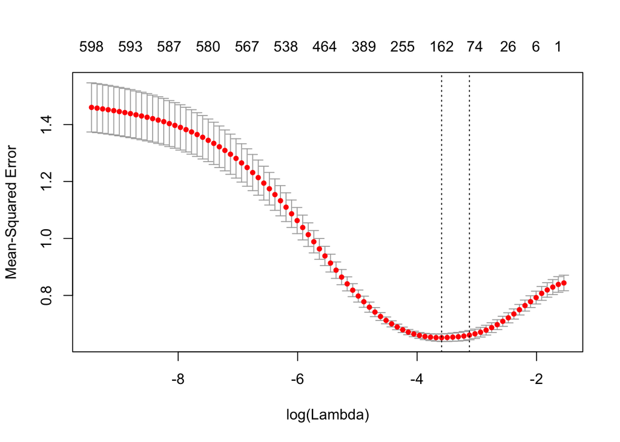

```r
predictions=predict(fit2, newx = as.matrix(joined_test[,V2:V601]))

#Grid search on optimal lambda value

cvfit2 = cv.glmnet(as.matrix(joined_train[,V2:V601]), as.numeric(joined_train[, Factor3]))
plot(cvfit2)
```

```r
cvfit2$lambda.min
```

```
## [1] 0.02761085
```

```r
predictions=predict(cvfit2, newx = as.matrix(joined_test[,V2:V601]), s = "lambda.min")
```

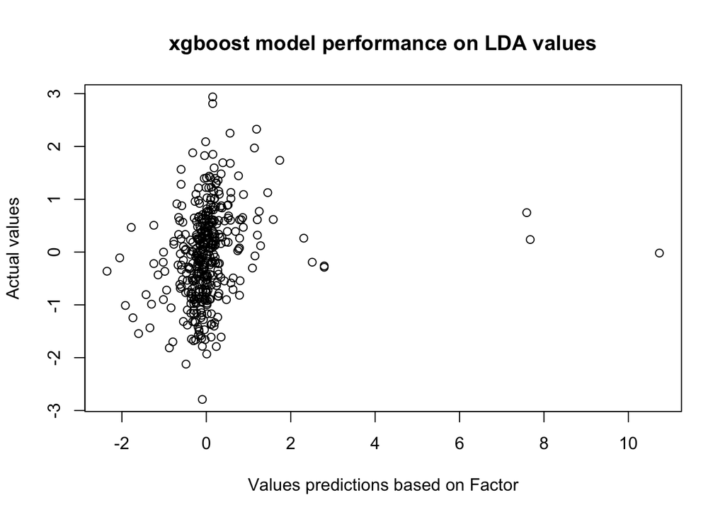

```r
plot(predictions, y_test_2, xlab="Values predictions based on Factor", ylab="Actual values", main="xgboost model performance on LDA values")
```

```r
mse_xgboost_model1 <- mean((joined_test[,Factor3] - predictions)^2)
mse_onlyUS <-  mean((joined_test[US,Factor3] - predictions[US])^2)
mse_canads <- mean((joined_test[Canada,Factor3] - predictions[Canada])^2)
mse_philippines <- mean((joined_test[Philippines,Factor3] - predictions[Philippines])^2)
mse_india <- mean((joined_test[India,Factor3] - predictions[India])^2)
mse_europe <- mean((joined_test[Europe,Factor3] - predictions[Europe])^2)
mse_australia <- mean((joined_test[Australia,Factor3] - predictions[Australia])^2)
mse_uk <- mean((joined_test[UK,Factor3] - predictions[UK])^2)

sd_xgboost_model1 <- sd((joined_test[,Factor3] - predictions)^2)
sd_onlyUS <-  sd((joined_test[US,Factor3] - predictions[US])^2)
sd_canads <- sd((joined_test[Canada,Factor3] - predictions[Canada])^2)
sd_philippines <- sd((joined_test[Philippines,Factor3] - predictions[Philippines])^2)
sd_india <- sd((joined_test[India,Factor3] - predictions[India])^2)
sd_europe <- sd((joined_test[Europe,Factor3] - predictions[Europe])^2)
sd_australia <- sd((joined_test[Australia,Factor3] - predictions[Australia])^2)
sd_uk <- sd((joined_test[UK,Factor3] - predictions[UK])^2)

MAE_xgboost <- median(abs(joined_test[,Factor3] - predictions))
MAE_onlyUS <-  median(abs((joined_test[US,Factor3] - predictions[US])))
MAE_canads <- median(abs((joined_test[Canada,Factor3] - predictions[Canada])))
MAE_philippines <- median(abs((joined_test[Philippines,Factor3] - predictions[Philippines])))
MAE_india <- median(abs((joined_test[India,Factor3] - predictions[India])))
MAE_europe <- median(abs((joined_test[Europe,Factor3] - predictions[Europe])))
MAE_australia <- median(abs((joined_test[Australia,Factor3] - predictions[Australia])))
MAE_uk <- median(abs((joined_test[UK,Factor3] - predictions[UK])))

R2=cor(predictions, y_test_2)^2
R2_onlyUS <-  cor(joined_test[US,Factor3], predictions[US])^2
R2_canads <- cor(joined_test[Canada,Factor3], predictions[Canada])^2
R2_philippines <- cor(joined_test[Philippines,Factor3], predictions[Philippines])^2
R2_india <- cor(joined_test[India,Factor3], predictions[India])^2
R2_europe <- cor(joined_test[Europe,Factor3], predictions[Europe])^2
R2_australia <- cor(joined_test[Australia,Factor3], predictions[Australia])^2
R2_uk <- cor(joined_test[UK,Factor3], predictions[UK])^2


MSElist=list("Total"=mse_xgboost_model1, "US"=mse_onlyUS, "Canada"=mse_canads, "Philippines"=mse_philippines, "India"=mse_india, "European Union"=mse_europe, "Australia"=mse_australia, "UK"=mse_uk)

SDlist=list("Total"=sd_xgboost_model1, "US"=sd_onlyUS, "Canada"=sd_canads, "Philippines"=sd_philippines, "India"=sd_india, "Europian Union"=sd_europe, "Australia"=sd_australia, "UK"=sd_uk)

MAElist=list("Total"=MAE_xgboost, "US"=MAE_onlyUS, "Canada"=MAE_canads, "Philippines"=MAE_philippines, "India"=MAE_india, "Europian Union"=MAE_europe, "Australia"=MAE_australia, "UK"=MAE_uk)

R2list=list("Total"=R2, "US"=R2_onlyUS, "Canada"=R2_canads, "Philippines"=R2_philippines, "India"=R2_india, "Europian Union"=R2_europe, "Australia"=R2_australia, "UK"=R2_uk)

LIST_glmnet_model2=round(mapply(cbind,MSElist, SDlist, MAElist, R2list),3)
rownames(LIST_glmnet_model2) <- c("MSE", "SD", "MAE", "R squared")
LIST_glmnet_model2
```

```
##           Total    US Canada Philippines  India European Union Australia
## MSE       1.366 0.555  1.240       0.736  8.929          0.799     0.807
## SD        7.044 0.780  2.128       0.944 24.253          1.352     1.311
## MAE       0.571 0.511  0.682       0.579  1.026          0.606     0.416
## R squared 0.036 0.194  0.012       0.062  0.122          0.094     0.008
##              UK
## MSE       0.528
## SD        0.621
## MAE       0.524
## R squared 0.104
```